# Partie II - 201902-fordgobike-tripdata

## par MBOCK MBOCK Georges Christian

## Aperçu de l'enquête

Dans cette exploration, j'ai voulu examiner les variables comme le sexe('member_gender'), la période du mois(en terme de semaine) aucours de laquelle débutent plus de trajet('start_Week'), le type de trajet ou 'type_trip'( type1, type2, type3, type4, type5 ou type6) et le fait que le vélo soit du type tout déplacement(ou non) qui pourraient être utilisées pour prédire le type d'utilisateur (Abonné ou Client).

## Aperçu de l'ensemble de données

Pour les trajets pour lesquels le sexe des utilisateurs est connu

type_1 ---> au plus 20minutes;

type_2 --->De 21 à 40minutes;

type_3 --->De 41 à 1heure;

type_4 --->De 1heure à 2.5heures;

type_5 --->De 2.5heures à 7heures;

type_6 ---> Pus de 7heures

Pour les trajets pour lesquels le sexe des utilisateurs n'est pas connu

type_1 ---> au plus 20minutes;

type_2 --->De 21 à 40minutes;

type_3 --->De 41 à 1heure;

type_4 --->De 1heure à 2.5heures;

type_5 --->De 2.5heures à 5.5heures;

type_6 ---> Pus de 5.5heures

Au final, le jeu de données principal a été divisé en deux sous jeux de données: Un jeu de données de 174952 enregistrements et 16 variables concernant les utilisateurs dont le sexe est connu et un deuxieème jeu de données de 8263 enregistrements et 14 variables concernant les utilisateurs dont les valeurs manquent pour les variables "memeber_gender" et "member_birth_year".

## 1) Repartition type d'utilisateurs

On remarque que ce soit les utilisateurs dont le sexe est connu ou non, nous avons plus d'Abonnés que de Clients.

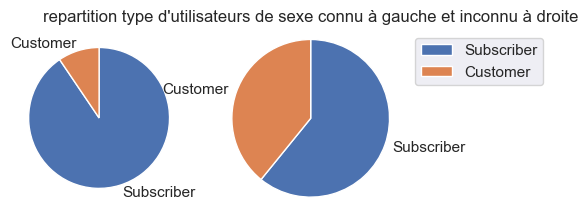

## 2) Relation entre durée du trajet et type de trajet ('duration_sec' Vs 'type_trip')

Le graphique suivant montre qu'il y'a globalement une relation entre durée et type de trajet.

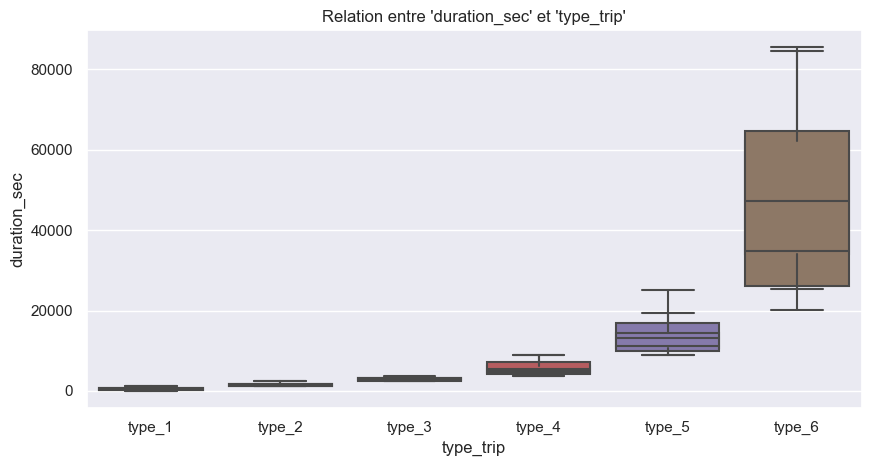

## 3) Influence du sexe sur le type d'utilisateur ('member_gender' Vs 'user_type')

Le fait d'un utilisateur soit un abonné ou un client ne semble pas être directement affecté par le son sexe.

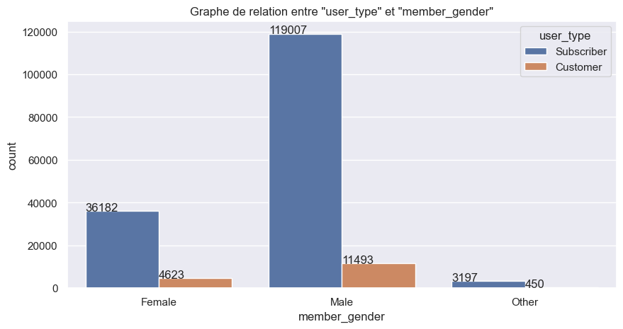

## 4) Influence du type trajet sur le type d'utilisateur ('type_trip' Vs 'user_type')

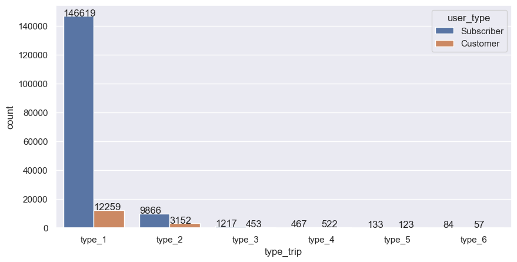

## 5) Influence du sexe sur le type d'utilisateur sachant que le type du trajet est le type5 ('Type_trajet' ='Type5'|'user_type' Vs 'menber_gender')

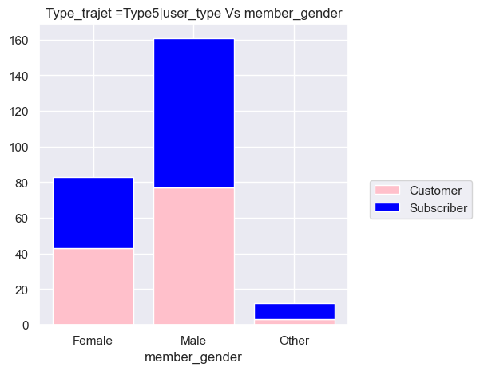

## 6) Influence du type de vélo sur le type d'utilisateur ('bike_share_for_all_trip' Vs 'user_type')

D'après ce graphe, nous remarquons que : Aucun utilisateur du type client ne dispose d'un vélo du type tout déplacement.A cet effet,il semble que le fait que le vélo soit du type tout déplacement ou pas semble influencer le type d'ultilisateur.

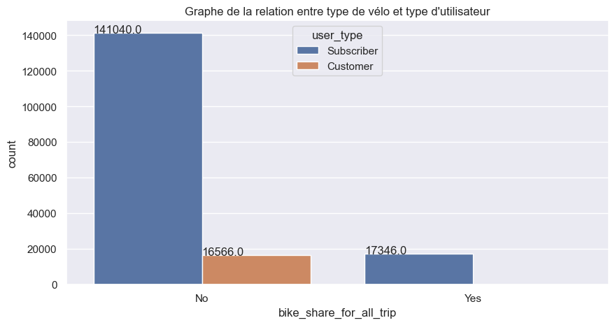

## 7) Influence du type de vélo sur le type d'utilisateur connaisant le sexe ('member_gender'=('Female' or 'Male' or 'Other')|'user_type' Vs 'bike_share_for_all_trip')

Nous obervons dans ce graphe que non seulement aucun client n'a utilisé le vélo de type tout déplacement mais les Abonnés de dont la vleur pour la variable 'member_gender' est 'Other' utilisent le plus les vélos du type tout déplacement et les Clients ayant 'Other' comme valeur de 'member_gender' utilisent moins les vélos de toutt déplacement.

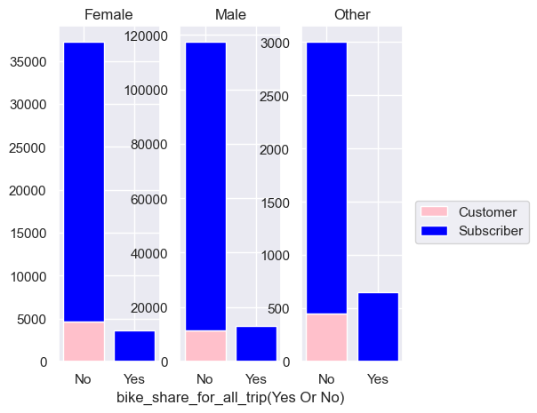

## 8) Influence du type de trajet sur le type d'utilisateur de sexe non connu ('user_type' Vs 'type_trip')

Ainsi, le fait d'être abonné ou client semble être directement influencé par le type du trajet.

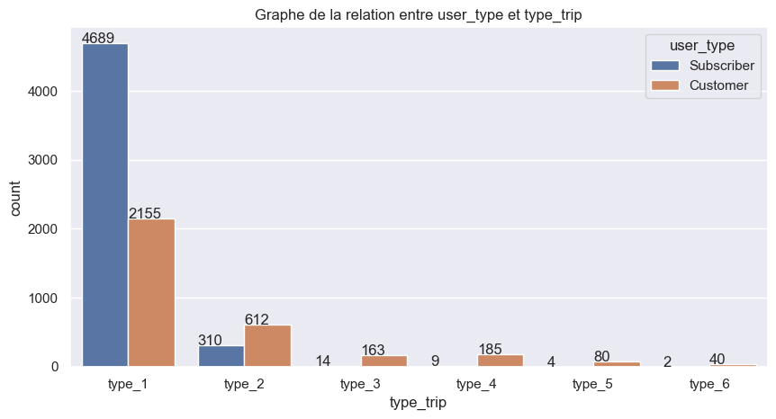